# KNN Algorithm

## What is KNN?

KNN is a supervised learning algorithm. It stores all training data and classifies the new data based on it's similarity from the stored data.

For example: Suppose we have data in which we have apple and oranges with data of their weight and size property.

Now when we get a test data(size and weight without knowing what fruit it is), the algorithm compares 5 nearest objects and in these 5 objects numbers of apples are 4 and orange is only one that the new object is classified as apple.

## What is K?

K is the number of objects that the KNN agorithms compares.

## Where KNN is used?

KNN is mostly used in recommendation system. Recommendation system is the system that we see on online shoping sites where these site show us the stuff that we are most likely to buy. It shows the the most relevant products to us.

Another good example of KNN alogithm is when we try to find some document or file on google and it shows us the most relevant documents or websites.

Image recognition is also an example of KNN.

## How does KNN works?

#### Step 1- Aquisition of data.

Lets say we have following data of apples and oranges. And the diamond shape is the unknown data.

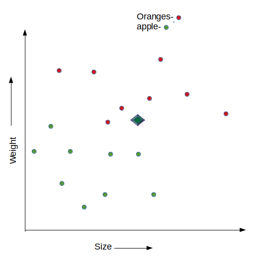

#### Step3- Locate K closest instances-

In this step we find out which are the K closest instances from the new point. In the following example lets say k=5

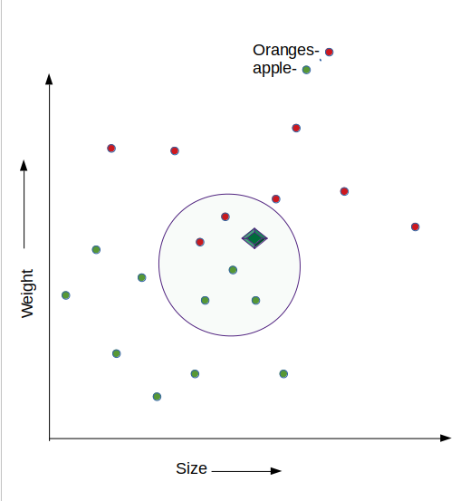

#### Step4- Find most suitable class-

Now we compare which class shows majority in these K instances and then we classify the new instance as that class. In the above diagram the new instance will be classified as apple because there are 3 apples out of 5 instances and oranges are only 2.

## Python implementation of KNN Algorithm

#### In following cell we will import all required libraries

```python
import numpy as np
import matplotlib.pyplot as plt
```

#### In next cell we will create dummy data

#### First two columns of train_data represents weight in grams and radius in cm

#### 3rd column of train_data reprents class of the instance where -

#### Apple = 0 and Orange = 1

#### test data contains an instance of testing our algorithm which should predict it as apple

```python
train_data = [
    [130,3.3,1],
    [140, 3.5,1],
    [160, 4,0],
    [120, 2.9,1],
    [110, 2.7,1],
    [150, 4.2,0],
    [125, 2.9,1],
    [130, 3,1],
    [157, 4.2,0],
    [161, 4.1,0],
    [163, 4.9,0],
]

test_data = [[170,5]]
test_label = [0] # apple
```

#### The following function euclidean calculates the distance between two points provided as point_one and point_two

```python
def euclidean(point_one, point_two, length):
    distance = 0
    #calculating distance between all the instances and the given test instance
    for x in range(length):
        distance = sqrt( ((point_one[0]-point_Two[0])**2) + ((point_one[0]-point_Two[0])**2))
    return distance
```

#### get_K_Neighbors function takes all the trainig data, test data and no of neighbors to find

#### Calculates distance of all training data instances with test data instance using euclidean function

#### Finds K nearest instances from training data , and returns them as list called neighbors

```python
import operator
def get_K_Neighbors(train_data, test_data, k):
    distances = []
    length = len(test_data)-1
    for x in range(len(train_data)):
        dist = euclidean(test_data, train_data[x], length)
        distances.append((train_data[x], dist))
    distances.sort(key=operator.itemgetter(1))
    neighbors = []
    for x in range(k):
        neighbors.append(distances[x][0])
    return neighbors
```

#### The predict funtion checks labels of all neighbors and counts if they belong to apple class or orange class.

#### After finding most probable class, it return the name of the fruit.

```python
def predict(test_data, train_data):
    k, orange, apple = 5,0,0
    neighbours = get_K_Neighbors(train_data, test_data,k)
    for i in range(k):
        if neighbours[-2] == 1:
            orange += 1
        if neighbours[-2] == 0:
            apple += 1
    if orange > apple:
        return "Orange"
    else:
        return "Apple"
```

```python
if __name__ == "__main__":
    prediction = predict(test_data, train_data)
    print("predicted fruit type : ",prediction)
```

[output not shown]